# WeRateData Analysis and Visualizations

## By Mohammad Albloushi

### Introduction

WeRateDogs is a Twitter account that rates people's dogs with a humorous comment about the dog. These ratings almost always have a denominator of 10. The numerators, though? Almost always greater than 10. 11/10, 12/10, 13/10, etc. Why? Because "they're good dogs Brent." WeRateDogs has over 7 million followers and has received international media coverage.

It was started in 2015 by college student Matt Nelson, Nelson, a golf management major at Campbell University in Buies Creek, North Carolina, was inspired by Weird Twitter and had amassed a 10,000-person following on his personal Twitter account.In 2015, he and a friend were at an Applebee's, when he set up a Twitter poll from his personal account asking if he should create a dog rating account; the positive response led him to create the account, which combines cute animals with irreverent snark.

WeRateDogs asks people to send photos of their dogs, then tweets selected photos rating and a humorous comment. Dogs are rated on a scale of one to ten, but are invariably given ratings in excess of the maximum, such as "13/10". Popular posts are re-posted on Instagram and Facebook. In 2017, Nelson started a spin-off Twitter account, Thoughts of Dog.

The account also has a branded game, a popular online store, and a book that was published in Fall, 2017. Nelson has two part-time staff working for the company, one of whom sorts through the 1,200 photos of dogs sent to him each day, and one to oversee the online shop.

### Retweets and Favorites

i Started with a scatter plot between retweets and favorites since it has a strong relationship so i can observe where most of retweets and favorites are.

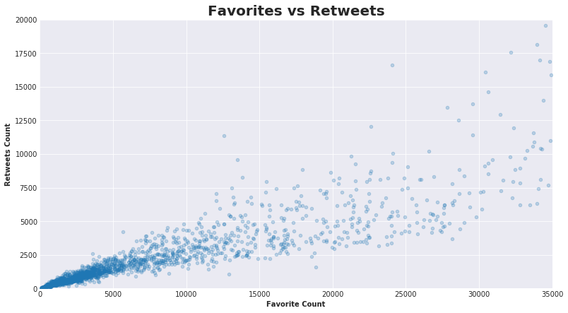

As we can see after limiting the x and y axis, We can observe that most of the retweets are around 2500 retweets or less and most of the favorites are around 10,000 favorites or less, we can also see that when ever retweet increases the favorite count increases as well which makes sense because since retweeting make more people see the tweet.

### Rating over Time

i wanted to know how is the rating over time have been, has it been increasing or decreasing? what's the most common rating?, so i created a plot to observe it

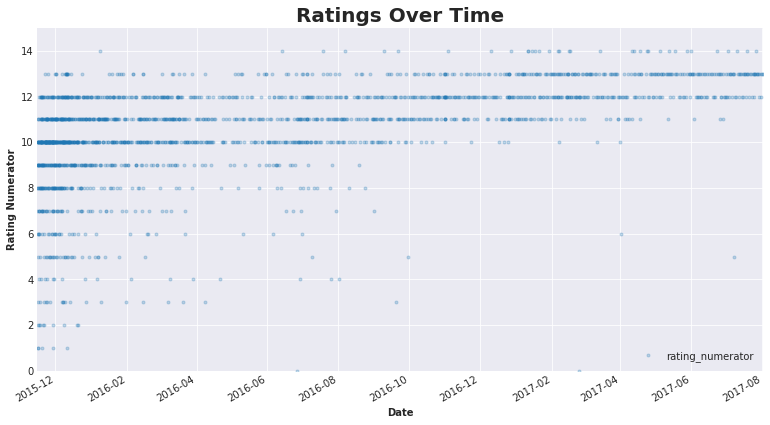

### Favorites and Retweets over Time

in this analysis i wanted to know if the retweet and favorite count is increasing for the account so i made a plot for favorite and retweet over time.

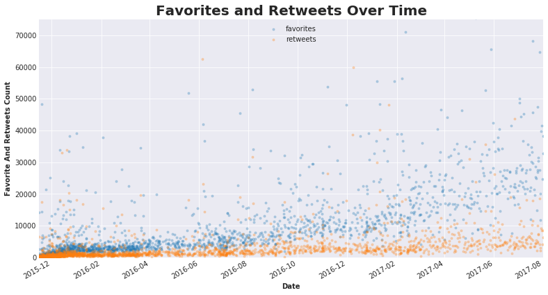

The first thing that i saw is there is is an increase in favorite over time, i Also can see when ever retweet is increasinh the favorite increases, also the good news is there is no decreasing in retweets and favorites as we can see the twitter account is in healthy condition, i found an interesting thing in this plot as well, which is seems that the amount of tweets been decreasing over time which we can see, from late 2015 and 2016 we can see more dots or retweets and favorites , but after 2016 there seem not to be a lot of retweets and favorites but the amount of favorites and retweets been increasing.

### Dog Types

Does dog type matter in rating, retweets and favorites?, this is what i wanted to know so i created a box plot for each.

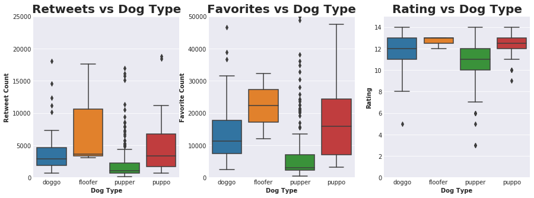

### The Most Predicted Breed

In here i wanted to see what is the most predicted breeds with high confidence so i made a bar plot.

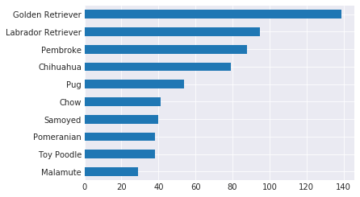

As We can see Golden Retriever is the most predicted breed followed up by a Labrador Retriever

### What's the most common name

i made a plot to know what is the most common name.

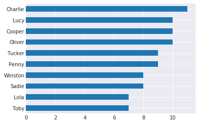

There doesn't seem to be a huge gap between names, but the most common name is **Charlie**.

### Where does tweets come from

in This plot it show's us the sources where tweets come from.

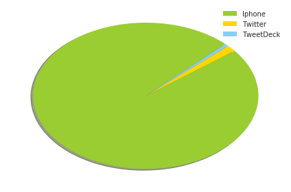

Almost every tweet come from an iphone and only a little bit came from Twitter or Tweet Deck